# iLykei Lecture Series Machine Learning Decision Trees Workshop 1: Recursive Binary Splitting

Y. Balasanov, © iLykei 2016-2022

# 1 Example on binary splitting

```r
(tree.data<-read.csv(file=paste(datapath,"binary_splitting_data.csv",sep="/")))
```

```
##             y         x1          x2
## 1   0.1622983  0.9264592  0.36617615
## 2   9.0339725  1.8228212 -1.32704085
## 3 -10.9623410 -1.6105669  2.41259221
## 4  -0.9408863 -0.2851098  0.06381535
## 5  -4.9025793 -0.3420730  1.54551478
```

## 1.1 Preparing functions for sums of squares

Prepare functions for calculating sum of squares of one split candidate `oneSplit(Data,Variable,Split)`, and for calculating sums of squares and split levels for all split candidates: `selectSplit(Data)`.

First function is `oneSplit(myData,myVariable,mySplit)`, where

- `myData` is the matrix of data including both response and predictors;
- `myVariable` is variable number among predictors, which splits the set;
- `mySplit` is the level at which the variable is split.

The steps of this function are:

1. Create an index `idx` of logical values separating rows of `myData` belonging to different regions after the split; `< mySplit` corresponds `idx==TRUE`;
2. Create subsets according to the `idx`;
3. Calculate mean values of response `y` for both subsets;
4. Calculate sums of squares of `y-mean(y)` for each subset and add them together; this is the value returned by function `oneSplit(myData,myVariable,mySplit)`

Second function is `selectSplit(myData)` which calls function `oneSplit(myData,myVariable,mySplit)` to decide which variable and at which level should make the next split.

The steps of the function are:

1. CReate variables `x1` and `x2` as sorted original predictor variables from small to large;
2. Create variable `splits` as data frame of two variables of midpoints of `x1` and `x2`; this variable is a data frame with variables names `x1` and `x2`;
3. Create variables `splits1.SS`, `splits2.SS` each of which is vector of sums of squares of all splits by the corresponding variable; this is done by function `oneSplit(myData,myVariable,mySplit)`
4. Create output in the form of list of 2 data frames:
- SS=data.frame(`splits1.SS`,`splits2.SS`)
- splits

(Try to do yourself)

```r
oneSplit<-function(myData,myVariable,mySplit){
  # myData: matrix of data
  # myVariable: number of variable that needs split 1:ncol(myData)
  # mySplit: split level
  idx<-myData[,myVariable+1]<mySplit # separate variable by mySplit
  subs1<-subset(myData,idx) # subset below mySplit
  subs2<-subset(myData,!idx) # subset above mySplit
  mean1<-mean(subs1$y) # mean of subset 1
  mean2<-mean(subs2$y) # mean of subset 2
  sum((subs1$y-mean1)^2)+sum((subs2$y-mean2)^2) # out: sum of sums of squares
}
selectSplit<-function(myData){
  # myData: data matrix including response in column 1
  x1<-sort(myData[,2]) # sort variable 1
  x2<-sort(myData[,3]) # sort variable 2
  nData<-length(myData[,1])-1 # number of splits

  # create splits
  splits<-data.frame(x1=sapply(1:nData,function(z) mean(c(x1[z],x1[z+1]))),
                     x2=sapply(1:nData,function(z) mean(c(x2[z],x2[z+1]))))

  # calculate sums of squares of all splits
  splits1.SS<-sapply(1:nData,function(z) oneSplit(myData,1,splits$x1[z]))
  splits2.SS<-sapply(1:nData,function(z) oneSplit(myData,2,splits$x2[z]))

  # out: sums of squares and splits
  list(SS=data.frame(splits1.SS=splits1.SS,splits2.SS=splits2.SS),
       splits=splits)
}
```

## 1.2 Find `node1` - the first split variable and split level.

(Try to do yourself)

```r
# splits for node 1
(node1<-selectSplit(tree.data))
```

```
## $SS
##   splits1.SS splits2.SS
## 1  103.74922   75.86822
## 2   78.16750  111.79267
## 3   90.30173   78.16750
## 4   75.86822  103.74922
##
## $splits
##           x1         x2
## 1 -0.9763200 -0.6316128
## 2 -0.3135914  0.2149957
## 3  0.3206747  0.9558455
## 4  1.3746402  1.9790535
```

```r
# which variable needs split? compare minimum SS for each variable
(splitVar<-ifelse(min(node1[["SS"]][,"splits1.SS"])>min(node1[["SS"]]["splits2.SS"]),2,1))
```

```
## [1] 1
```

```r
# where is to split? row number corresponding to smallest SS
(splitNum<-as.numeric(ifelse(splitVar==1,
                             which.min(node1[["SS"]][,"splits1.SS"]),
                             which.min(node1[["SS"]][,"splits2.SS"]))))
```

```
## [1] 4
```

```r
# what is the split level? row splitNum in column splitVar
(splitLevel.1<-node1[["splits"]][splitNum,splitVar])
```

```
## [1] 1.37464
```

## 1.3 Create 2 regions $R_1$ and $R_2$ breaking the initial sample.

What are the regions?

```r
# create subsets based on the split
(Reg1<-subset(tree.data,tree.data[,splitVar+1]>=splitLevel.1))
```

```
##          y       x1        x2
## 2 9.033972 1.822821 -1.327041
```

```r
(Reg2<-subset(tree.data,tree.data[,splitVar+1]< splitLevel.1))
```

```
##             y         x1         x2
## 1   0.1622983  0.9264592 0.36617615
## 3 -10.9623410 -1.6105669 2.41259221
## 4  -0.9408863 -0.2851098 0.06381535
## 5  -4.9025793 -0.3420730 1.54551478
```

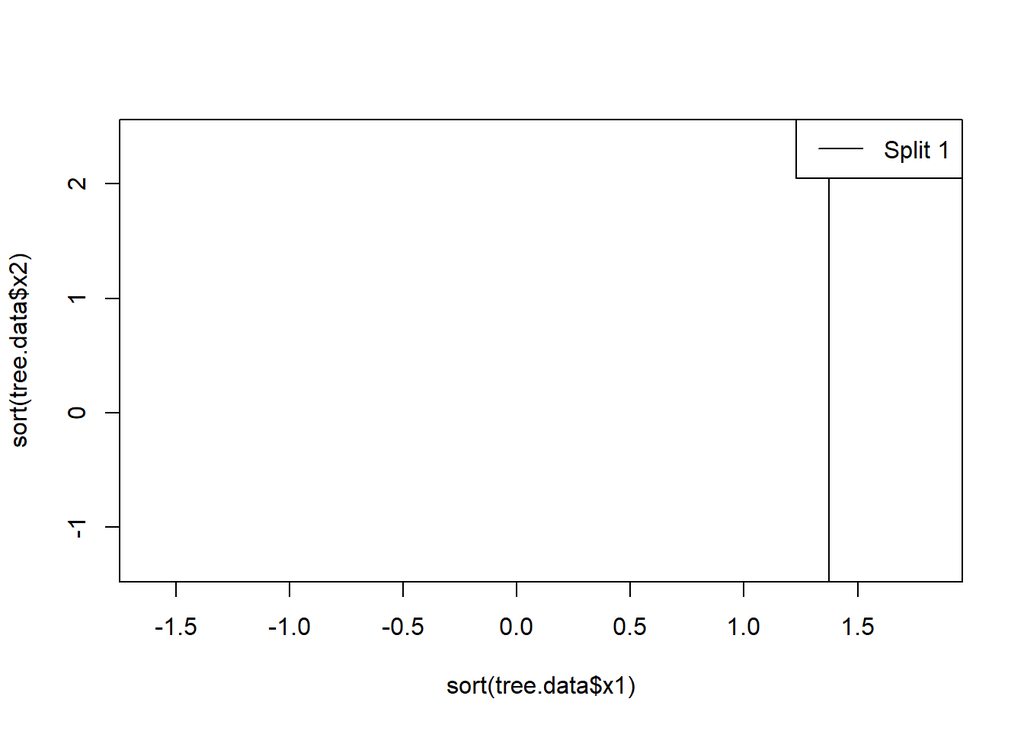

```r
plot(sort(tree.data$x1),sort(tree.data$x2),type="n")
if (splitVar==1) {
  abline(v=splitLevel.1)
} else {
  abline(h=splitLevel.1)
}
legend("topright",legend=c("Split 1"),lty=1)
```

## 1.4 Which of the regions $R_1$, $R_2$ needs a split?

```r
(node2<-selectSplit(Reg1))
```

```
## $SS
##   splits1.SS splits2.SS
## 1          0          0
## 2          0          0
##
## $splits
##         x1        x2
## 1       NA        NA
## 2 1.822821 -1.327041
```

Looks like leaf.

```r
(node2<-selectSplit(Reg2))
```

```
## $SS
##   splits1.SS splits2.SS
## 1   14.18834   62.04377
## 2   18.96886   18.96886
## 3   50.94843   14.18834
##
## $splits
##           x1        x2
## 1 -0.9763200 0.2149957
## 2 -0.3135914 0.9558455
## 3  0.3206747 1.9790535
```

This needs further split.

## 1.5 Split $R_2$ by creating regions $R_3$ and $R_4$

(Try to do yourself)

```r
(splitVar<-ifelse(min(node2[["SS"]][,"splits1.SS"])>min(node2[["SS"]]["splits2.SS"]),2,1))
```

```
## [1] 1
```

## 1.6 What are the split variables and split levels?

(Try to do yourself)

```r
(splitNum<-as.numeric(ifelse(splitVar==1,
                             which.min(node2[["SS"]][,"splits1.SS"]),
                             which.min(node2[["SS"]][,"splits2.SS"]))))
```

```
## [1] 1
```

```r
(splitLevel.2<-node2[["splits"]][splitNum,splitVar])
```

```
## [1] -0.97632
```

## 1.7 Create the next breakup.

(Try to do yourself)

```r
(Reg3<-subset(Reg2,Reg2[,splitVar+1]>=splitLevel.2))
```

```
##            y         x1         x2
## 1  0.1622983  0.9264592 0.36617615
## 4 -0.9408863 -0.2851098 0.06381535
## 5 -4.9025793 -0.3420730 1.54551478
```

```r
(Reg4<-subset(Reg2,Reg2[,splitVar+1]< splitLevel.2))
```

```
##           y        x1       x2
## 3 -10.96234 -1.610567 2.412592
```

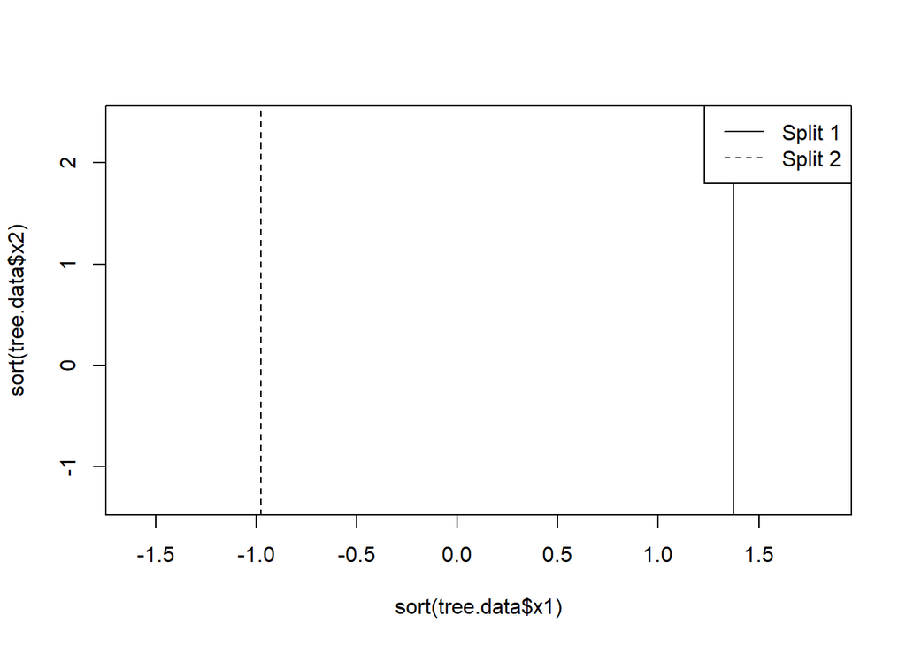

```r
plot(sort(tree.data$x1),sort(tree.data$x2),type="n")
if (splitVar==1) {
  abline(v=splitLevel.1)
} else {
  abline(h=splitLevel.1)
}
if (splitVar==1) {
  abline(v=splitLevel.2,lty=2)
} else {
  abline(h=splitLevel.2,lty=2)
}
legend("topright",legend=c("Split 1","Split 2"),lty=c(1,2))
```

## 1.8 Which region needs a split?

(Try to do yourself)

```r
(node3<-selectSplit(Reg4))
```

```
## $SS
##   splits1.SS splits2.SS
## 1          0          0
## 2          0          0
##
## $splits
##          x1       x2
## 1        NA       NA
## 2 -1.610567 2.412592
```

Found a leaf in $R_4$.

```r
(node3<-selectSplit(Reg3))
```

```
## $SS
##   splits1.SS splits2.SS
## 1  0.6085082 12.8264924
## 2  7.8475055  0.6085082
##
## $splits
##           x1        x2
## 1 -0.3135914 0.2149957
## 2  0.3206747 0.9558455
```

This needs further split

## 1.9 Select next split variable for $R_3$.

(Try to do yourself)

```r
(splitVar<-ifelse(min(node3[["SS"]][,"splits1.SS"])>min(node3[["SS"]]["splits2.SS"]),2,1))
```

```
## [1] 1
```

```r
(splitNum<-as.numeric(ifelse(splitVar==1,
                             which.min(node3[["SS"]][,"splits1.SS"]),
                             which.min(node1[["SS"]][,"splits2.SS"]))))
```

```
## [1] 1
```

```r
(splitLevel.3<-node3[["splits"]][splitNum,splitVar])
```

```
## [1] -0.3135914
```

## 1.10 Create regions $R_5$ and $R_6$.

(Try to do yourself)

```r
(Reg5<-subset(Reg3,Reg3[,splitVar+1]>=splitLevel.3))
```

```
##            y         x1         x2
## 1  0.1622983  0.9264592 0.36617615
## 4 -0.9408863 -0.2851098 0.06381535
```

```r
(Reg6<-subset(Reg3,Reg3[,splitVar+1]< splitLevel.3))
```

```
##           y        x1       x2
## 5 -4.902579 -0.342073 1.545515
```

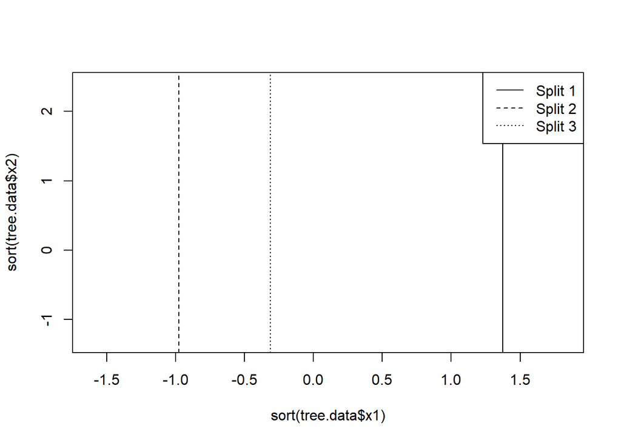

```r
plot(sort(tree.data$x1),sort(tree.data$x2),type="n")
if (splitVar==1) {
  abline(v=splitLevel.1)
} else {
  abline(h=splitLevel.1)
}
if (splitVar==1) {
  abline(v=splitLevel.2,lty=2)
} else {
  abline(h=splitLevel.2,lty=2)
}
if (splitVar==1) {
  abline(v=splitLevel.3,lty=3)
} else {
  abline(h=splitLevel.3,lty=3)
}
legend("topright",legend=c("Split 1","Split 2","Split 3"),lty=c(1,2,3))
```

## 1.11 Find mean values of all regions.

Since all regions, but $R_5$ contain only one observation need to average only $R_5$.

```r
mean(Reg5$y)
```

```
## [1] -0.389294
```

```r
(nodeMeans<-sapply(1:6, function(z) mean(get(paste0("Reg",z))$y)))
```

```
## [1]   9.033972  -4.160877  -1.893722 -10.962341  -0.389294  -4.902579
```

## 1.12 Summary

1. Initial split is at $X_1$ at level 1.3746402.
2. Second split is at $X_1$ at level -0.97632.
3. Third split is at $X_1$ at level -0.3135914.

## 1.13 Check the splits against fitted tree.

```r
suppressWarnings(library(rpart))
suppressWarnings(library(rpart.plot))
```

```r
built.tree<-rpart(y~., data=tree.data,
                        control = rpart.control(minbucket=1,cp=.0001))
printcp(built.tree)
```

```
##
## Regression tree:
## rpart(formula = y ~ ., data = tree.data, control = rpart.control(minbucket = 1,
##     cp = 1e-04))
##
## Variables actually used in tree construction:
## [1] x1 x2
##
## Root node error: 215.15/5 = 43.03
##
## n= 5
##
##         CP nsplit rel error xerror    xstd
## 1 0.647373      0 1.0000000 1.5625 0.76992
## 2 0.286681      1 0.3526270 1.9551 0.50099
## 3 0.063118      2 0.0659458 1.7010 0.30014
## 4 0.000100      3 0.0028283 1.3471 0.22608
```

```r
(best.CP = built.tree$cptable[which.min(built.tree$cptable[,"xerror"]),"CP"])
```

```
## [1] 1e-04
```

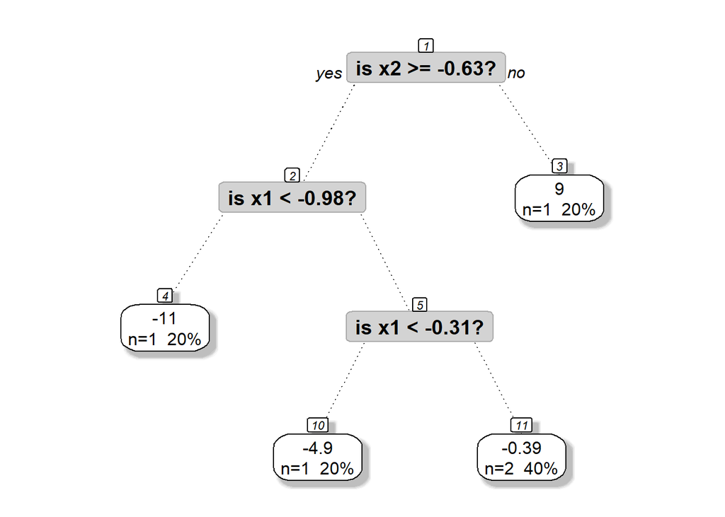

```r
prp(built.tree,extra=101, # display prob of classes in the node
    branch=.5, # change angle of branch lines
    shadow.col="gray", # shadows under the leaves
    branch.lty=3, # draw branches using dotted lines
    split.cex=1.2, # make the split text larger than the node text
    split.prefix="is ", # put "is " before split text
    split.suffix="?", # put "?" after split text
    split.box.col="lightgray", # lightgray split boxes (default is white)
    split.border.col="darkgray", # darkgray border on split boxes
    split.round=.5,
    nn=TRUE)
```

Compare the top numbers in each leaf with the node mean values

```r
nodeMeans
```

```
## [1]   9.033972  -4.160877  -1.893722 -10.962341  -0.389294  -4.902579
```